# APSTA-GE: 2003 Intermediate Quantitative Methods

Birth Weight Exercise Sample Solution

23 November 2020

## Instructions

In this data analysis project, we will examine various factors that may be associated with baby’s birth weight.

## Question 1

Load the dataset `BirthWeight_Study.csv`. Report the sample size and the number of variables.

**Answer: Q1**

```r
dat <- read.csv("../data/BirthWeight_Study.csv")

dim(dat)
```

```
## [1] 70607    15
```

Sample size: $70,607$.

Number of variables: $15$

## Question 2

Summarize the outcome variable `BirthWeight`.

### Question 2a

What is the unit of birth weight?

**Answer: Q2a**

```r
range(dat$BirthWeight)
```

```
## [1]  132.6566 5839.9863
```

The unit of birth weight is gram.

### Question 2b

Report mean, variance and standard deviation.

**Answer: Q2b**

```r
mean(dat$BirthWeight)
```

```
## [1] 3542.056
```

```r
var(dat$BirthWeight)
```

```
## [1] 560496
```

```r
sd(dat$BirthWeight)
```

```
## [1] 748.6628
```

### Question 2c

Plot a histogram of the variable.

**Answer: Q2c**

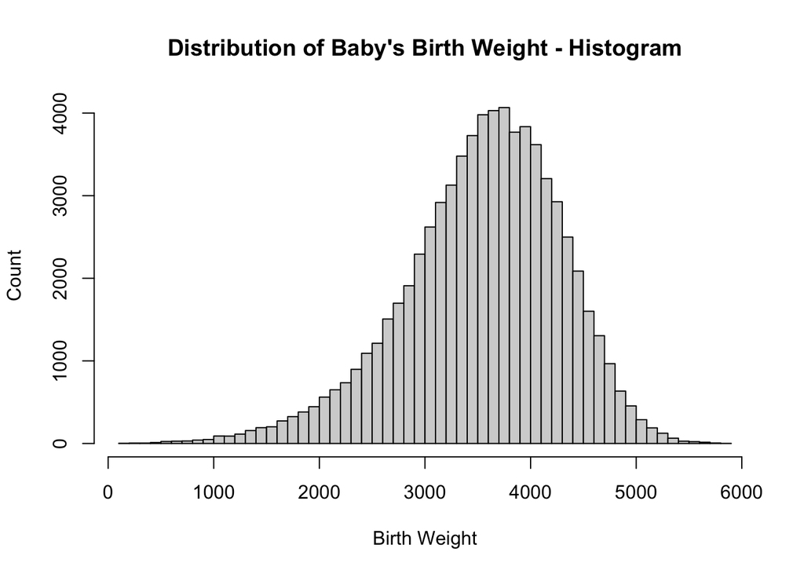

```r
hist(dat$BirthWeight, xlab = "Birth Weight", ylab = "Count",
     breaks = 50, # Set 50 bins
     main = "Distribution of Baby's Birth Weight - Histogram")
```

### Question 2d

Check whether there are any obvious outliers.

**Answer: Q2d**

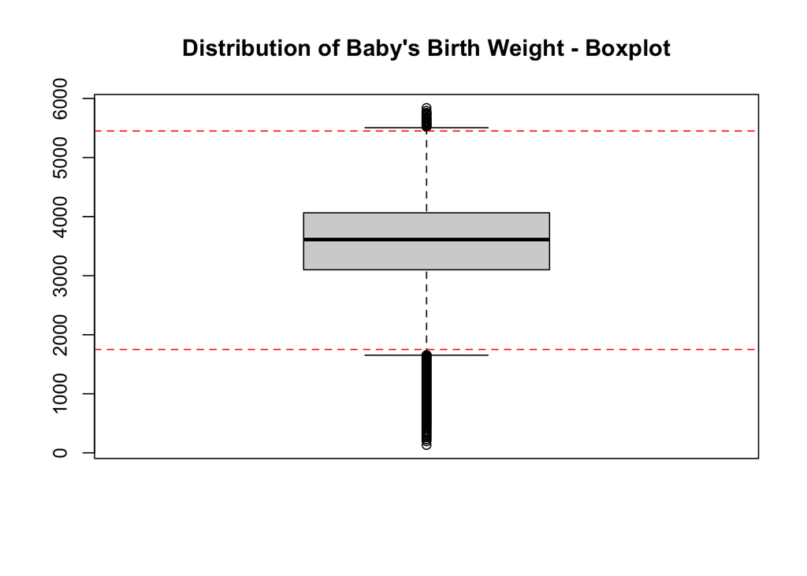

```r
boxplot(dat$BirthWeight, main = "Distribution of Baby's Birth Weight - Boxplot")
abline(h = 1750, lty = "dashed", col = "red")
abline(h = 5450, lty = "dashed", col = "red")
```

Any birth weight records that are greater than 5450 grams or smaller than 1750 grams should be considered as outliers.

## Question 3

Take a look at the list of the other variables.

### Question 3a

`Year`: calendar year when the babies were born

`Race`: race of mother (1 = white, 2 = black, 3 = other)

`GestWeek`: gestational weeks

`Age35`: whether mother is older than 35 at the time of child birth

`Smoke`: whether mother smokes

`Ed`: mother’s level of education

`Hyperten`: whether mother has hypertension

`SecondBirth`: whether the baby is first birth (secondbirth = 0 if first birth)

`GestDiabetes`: whether mother has gestational diabetes

`InfantSex`: gender of the baby

`BMI`: mother’s BMI before pregnancy

`WeightGain`: mother’s weight gain during pregnancy

`FatherAge35`: whether father is older than 35 years old

`FatherBMI`: fatherBMI

### Question 3b

Generate summary statistics for each of these variables. Pay attention to variable types.

**Answer: Q3b**

```r
str(dat)
```

```
## 'data.frame':    70607 obs. of  15 variables:
##  $ BirthWeight : num  3067 2652 4652 3380 3046 ...
##  $ Year        : int  2010 2006 2010 2005 2010 2005 2009 2006 1997 2011 ...
##  $ Race        : int  1 1 2 2 1 1 1 1 1 1 ...
##  $ GestWeek    : int  39 36 39 38 37 39 39 36 38 34 ...
##  $ Age35       : int  0 0 0 0 0 0 1 0 0 0 ...
##  $ Smoke       : int  0 1 0 0 0 0 0 0 0 0 ...
##  $ Ed          : int  1 0 0 1 0 1 1 0 0 0 ...
##  $ Hyperten    : int  0 1 0 0 0 0 0 0 0 0 ...
##  $ SecondBirth : int  1 1 1 1 1 1 1 1 0 1 ...
##  $ GestDiabetes: int  0 0 0 0 0 0 0 0 0 0 ...
##  $ InfantSex   : int  2 2 1 1 1 1 1 2 1 2 ...
##  $ BMI         : int  2 2 3 2 2 2 2 2 2 2 ...
##  $ WeightGain  : int  2 3 3 3 3 3 3 2 3 3 ...
##  $ FatherAge35 : int  0 0 0 1 0 0 1 0 0 0 ...
##  $ FatherBMI   : num  18 25.2 23.7 19.7 26.1 ...
```

There are only two numeric variables: `BirthWeight` and `FatherBMI`. All other variables are categorical and are dummy coded.

We can create a function that generates summary statistics.

```r
generate_summary_statistics <- function(dat, is_num) {
  # Generate summary statistics of the dataset, output as data frames
  # Param: dat: the input dataset
  # Param: is_num: type of output to generate:
  #        TRUE for numeric variables; FALSE for categorical.
  cols <- ncol(dat)
  summary_num <- list()
  summary_cat <- list()
  index <- 1
  if (is_num) {
    for (col in 1:cols) {
      col_type <- class(dat[, col])
      if (col_type == "numeric") {
        summary_num[[index]] <- summary(dat[, col])
        names(summary_num)[index] <- colnames(dat)[col]
        index <- index + 1
      }
    }
    summary_num
  } else {
    for (col in 1:cols) {
      col_type <- class(dat[, col])
      if (col_type == "integer") {
        dat[, col] <- as.factor(dat[, col])
        summary_cat[[index]] <- table(dat[, col])
        names(summary_cat)[index] <- colnames(dat)[col]
        index <- index + 1
      }
    }
    summary_cat
  }
}
```

Let’s apply our function.

```r
generate_summary_statistics(dat, is_num = TRUE)
```

```
## $BirthWeight
##    Min. 1st Qu.  Median    Mean 3rd Qu.    Max.
##   132.7  3100.6  3611.1  3542.1  4065.2  5840.0
##
## $FatherBMI
##    Min. 1st Qu.  Median    Mean 3rd Qu.    Max.
##    4.89   23.66   27.02   27.04   30.44   51.31
```

```r
generate_summary_statistics(dat, is_num = FALSE)
```

```
## $Year
##
## 1997 1998 1999 2000 2001 2002 2003 2004 2005 2006 2007 2008 2009 2010 2011
## 4765 4667 4798 4608 4651 4582 4785 4622 4697 4688 4870 4751 4642 4745 4736
##
## $Race
##
##     1     2     3
## 57187 10283  3137
##
## $GestWeek
##
##    21    22    23    24    25    26    27    28    29    30    31    32    33
##    47    82   126   155   187   135   338   506   657   816   810  1565  2353
##    34    35    36    37    38    39    40    41    42
##  3322  4053  8743  9740 10502 12000 10377  4000    93
##
## $Age35
##
##     0     1
## 60025 10582
##
## $Smoke
##
##     0     1
## 60414 10193
##
## $Ed
##
##     0     1
## 42000 28607
##
## $Hyperten
##
##     0     1     2     3
## 54458  6713  2149  7287
##
## $SecondBirth
##
##     0     1
```

[output cut: 11 more lines]

```
##
## $BMI
##
##     1     2     3     4
##  3489 40255 14036 12827
##
## $WeightGain
##
##     1     2     3
## 10823 21154 38630
##
## $FatherAge35
##
##     0     1
## 57591 13016
```

### Question 3c

Which ones of these variables do you think may be related to baby birth weight (how much do you know about determinants of baby’s birth weight? A quick wiki check can be helpful)

**Answer: Q3c**

This is an open question. The following variables may be related to baby’s birth weight.

`GestWeek`, `Age35`, `Smoke`, `Ed`, `Hyperten`, `SecondBirth`, `GestDiabetes`, `InfantSex`, `BMI`, `WeightGain`.

## Question 4

Researchers are particularly interested in the racial differences in birth weights.

### Question 4a

Fit a regression model using `Race` as predictors to compare birth weights across different race.

**Answer: Q4a**

```r
dat$Race <- as.factor(dat$Race)

mod_Q4a <- lm(BirthWeight ~ Race, data = dat)
summary(mod_Q4a)
```

```
##
## Call:
## lm(formula = BirthWeight ~ Race, data = dat)
##
## Residuals:
##     Min      1Q  Median      3Q     Max
## -3344.0  -439.5    67.6   522.4  2323.5
##
## Coefficients:
##             Estimate Std. Error t value Pr(>|t|)
## (Intercept) 3572.425      3.120 1145.12   <2e-16 ***
## Race2       -163.423      7.991  -20.45   <2e-16 ***
## Race3       -147.837     13.680  -10.81   <2e-16 ***
## ---
## Signif. codes:  0 '***' 0.001 '**' 0.01 '*' 0.05 '.' 0.1 ' ' 1
##
## Residual standard error: 746 on 70604 degrees of freedom
## Multiple R-squared:  0.007027,   Adjusted R-squared:  0.006998
## F-statistic: 249.8 on 2 and 70604 DF,  p-value: < 2.2e-16
```

We now know that `Race` is another variable that related to baby’s birth weight.

### Question 4b

How does racial gap change over time? What regression model would you use to answer this question?

**Answer: Q4b**

We can fit a regression model that uses `Year` and `Race` to predict `BirthWeight`.

Linear:

$$\text{Birth Weight} = \beta_0 + \beta_1 \cdot \text{Race} + \beta_2 \cdot \text{Year} + \varepsilon$$

Linear with interactive term:

$$\text{Birth Weight} = \beta_0 + \beta_1 \cdot \text{Race} + \beta_2 \cdot \text{Year} + \beta_3 \cdot \text{Race} \cdot \text{Year} + \varepsilon$$

## Question 5

Create a subset of data for 2011. Conduct a more detailed analysis on the associations of various factors with birth weight.

```r
dat_2011 <- subset(dat, Year == 2011)
```

### Question 5a

Start with the model that only includes race.

**Answer: Q5a**

```r
dat_2011$Race <- as.factor(dat_2011$Race)
mod_Q5a <- lm(BirthWeight ~ Race, data = dat_2011)
summary(mod_Q5a)
```

```
##
## Call:
## lm(formula = BirthWeight ~ Race, data = dat_2011)
##
## Residuals:
##      Min       1Q   Median       3Q      Max
## -2966.59  -442.81    69.16   527.89  2067.72
##
## Coefficients:
##             Estimate Std. Error t value Pr(>|t|)
## (Intercept)  3555.89      12.04 295.238  < 2e-16 ***
## Race2        -141.29      29.93  -4.720 2.43e-06 ***
## Race3        -124.57      53.61  -2.324   0.0202 *
## ---
## Signif. codes:  0 '***' 0.001 '**' 0.01 '*' 0.05 '.' 0.1 ' ' 1
##
## Residual standard error: 742.5 on 4733 degrees of freedom
## Multiple R-squared:  0.005444,   Adjusted R-squared:  0.005023
## F-statistic: 12.95 on 2 and 4733 DF,  p-value: 2.455e-06
```

### Question 5b

Include the rest of the variables in the model. Do we need to include “`Year`” to analyze this subset of data? Why or why not? Pay attention to variable types!

**Answer:**

Since this subset is for 2011, we do not need to include `Year` in our model.

```r
# Convert categorical variables to factor
cols <- ncol(dat_2011)
for (col in 1:cols) {
  if (class(dat_2011[, col]) == "integer") {
    dat_2011[, col] <- as.factor(dat_2011[, col])
  }
}
```

```r
# Remove column Year
index_of_col_year <- which(colnames(dat_2011) == "Year")
dat_2011 <- dat_2011[, -index_of_col_year]
```

```r
mod_Q5b <- lm(BirthWeight ~ ., data = dat_2011)
summary(mod_Q5b)
```

```
##
## Call:
## lm(formula = BirthWeight ~ ., data = dat_2011)
##
## Residuals:
##      Min       1Q   Median       3Q      Max
## -1640.72  -272.74     1.18   274.39  1441.49
##
## Coefficients:
##                Estimate Std. Error t value Pr(>|t|)
## (Intercept)   1333.6038   234.6233   5.684 1.40e-08 ***
## Race2         -168.1574    16.5089 -10.186  < 2e-16 ***
## Race3          -67.2497    28.8993  -2.327  0.02001 *
## GestWeek22    -440.2133   304.8820  -1.444  0.14884
## GestWeek23    -136.6407   259.9632  -0.526  0.59918
## GestWeek24     312.2951   257.5626   1.213  0.22538
## GestWeek25     101.1093   259.9824   0.389  0.69736
## GestWeek26     368.8560   266.3720   1.385  0.16620
## GestWeek27     395.0235   249.0260   1.586  0.11274
## GestWeek28     542.2480   239.6815   2.262  0.02372 *
## GestWeek29     757.3953   237.3011   3.192  0.00142 **
## GestWeek30     981.3803   238.9263   4.107 4.07e-05 ***
## GestWeek31    1116.5960   235.2020   4.747 2.12e-06 ***
## GestWeek32    1207.0135   233.9408   5.159 2.58e-07 ***
## GestWeek33    1458.8484   232.4827   6.275 3.81e-10 ***
## GestWeek34    1546.6797   231.9701   6.668 2.90e-11 ***
## GestWeek35    1819.1750   231.6812   7.852 5.03e-15 ***
## GestWeek36    2005.1376   231.0598   8.678  < 2e-16 ***
## GestWeek37    2217.9611   230.9883   9.602  < 2e-16 ***
## GestWeek38    2460.3338   230.9523  10.653  < 2e-16 ***
## GestWeek39    2679.2695   230.9089  11.603  < 2e-16 ***
## GestWeek40    2897.1039   230.9710  12.543  < 2e-16 ***
## GestWeek41    3184.9550   231.9097  13.734  < 2e-16 ***
## GestWeek42    3286.8588   304.9435  10.779  < 2e-16 ***
## Age351          -7.5855    30.1209  -0.252  0.80118
## Smoke1        -206.8696    18.3286 -11.287  < 2e-16 ***
## Ed1             28.2198    11.9690   2.358  0.01843 *
## Hyperten1      -35.5013    20.0415  -1.771  0.07656 .
## Hyperten2       -5.2028    34.5424  -0.151  0.88028
## Hyperten3      -32.3867    20.1754  -1.605  0.10850
## SecondBirth1  -111.4745    12.4651  -8.943  < 2e-16 ***
## GestDiabetes1   70.6273    35.0845   2.013  0.04417 *
## InfantSex2    -158.7984    11.6042 -13.685  < 2e-16 ***
## BMI2           -11.5385    28.0177  -0.412  0.68048
## BMI3           -69.8529    29.7207  -2.350  0.01880 *
## BMI4            50.0467    30.5602   1.638  0.10156
## WeightGain2     93.6472    17.8926   5.234 1.73e-07 ***
## WeightGain3    217.8412    16.4939  13.207  < 2e-16 ***
## FatherAge351    25.7740    27.9930   0.921  0.35724
## FatherBMI       -0.5151     1.1419  -0.451  0.65196
## ---
## Signif. codes:  0 '***' 0.001 '**' 0.01 '*' 0.05 '.' 0.1 ' ' 1
##
## Residual standard error: 398 on 4696 degrees of freedom
## Multiple R-squared:  0.7164, Adjusted R-squared:  0.7141
## F-statistic: 304.2 on 39 and 4696 DF,  p-value: < 2.2e-16
```

### Question 5c

Compare the race only model with the “big” model, what differences do you notice? What happens to racial gap in birth weight after we control for other variables? Which other variables are significantly associated with Birth weight? Anything surprising? What’s the overall model fit (R squares) of the “big” model? Is it much greater than the “small” model? Which variables contribute most to this change?

**Answer: Q5c**

After fitting the “big” model, we are able to explain part of the residuals in our original “small” model. After controlling other variables, although the coefficient estimates change, the racial gap does not change fundamentally.

Variables that are significantly associated:

`GestWeek`, `Smoke`, `Ed`, `SecondBirth`, `GestDiabetes`, `InfantSex`, `WeightGain`.`

Overall model fit of the big model:

```r
summary(mod_Q5b)$r.squared
```

```
## [1] 0.7164309
```

It is much greater than the small model. `GestWeek` contributes the most.

### Question 5d

Do you think the “big” model is the best model that characterizes the relationship between birth weight and other factors? Why and why not? What are other ways that you would like to explore to improve the model fit and model interpretation?

**Answer:**

This is an open question. We should also fit linear regression models with interactive terms because variables, such as `GestDiabetes` and `WeightGain` might be correlated.